# Practical Machine Learning - Prediction Assignment

## Background

Using devices such as Jawbone Up, Nike FuelBand, and Fitbit it is now possible to collect a large amount of data about personal activity relatively inexpensively. These type of devices are part of the quantified self movement – a group of enthusiasts who take measurements about themselves regularly to improve their health, to find patterns in their behavior, or because they are tech geeks. One thing that people regularly do is quantify how much of a particular activity they do, but they rarely quantify how well they do it. In this project, your goal will be to use data from accelerometers on the belt, forearm, arm, and dumbell of 6 participants. They were asked to perform barbell lifts correctly and incorrectly in 5 different ways. More information is available from the website here: http://web.archive.org/web/20161224072740/http:/groupware.les.inf.puc-rio.br/har (see the section on the Weight Lifting Exercise Dataset).

## Data

The data for this project come from this source: http://web.archive.org/web/20161224072740/http:/groupware.les.inf.puc-rio.br/har. If you use the document you create for this class for any purpose please cite them as they have been very generous in allowing their data to be used for this kind of assignment.

The training data for this project are available here:

https://d396qusza40orc.cloudfront.net/predmachlearn/pml-training.csv

The test data are available here:

https://d396qusza40orc.cloudfront.net/predmachlearn/pml-testing.csv

```r
# Load the data, removing the likely unavialbe information
Test <- read.csv("pml-testing.csv", na.strings = c("", "NA", "#DIV/0!"))
Train <- read.csv("pml-training.csv", na.strings = c("", "NA", "#DIV/0!"))
```

### Initial Exploration & Cleaning

Need to explore the dataset in order to have an improved understanding of the available data, before attempting to tidy the data.

```r
# Dimensions of data
dim(Train)
head(Train)
summary(Train)
sapply(Train, class)
table(Train$classe)
duplicated(colnames(Train))
```

[output not shown]

> The training data has 19622 instances with 160 attributes, which might be worth reducing. Experimented with removing data columns with high percentages of NA information. Removing either 50% or 95% NAs both resulted in 60 attributes remaining.

```r
CTrain <- Train[, -which(colMeans(is.na(Train)) > .5)]
dim(CTrain)
```

```
## [1] 19622    60
```

```r
CTrain <- Train[, -which(colMeans(is.na(Train)) > .95)]
dim(CTrain)
```

```
## [1] 19622    60
```

### Explore distribution breakdown

Continued exploring the kind of data inside the dataset. Played around with the users versus data as well as the expected classe versus data pertinent to the course. Then removed the superfluous columns in order to streamline and improve the modeling predictions.

```r
levels(CTrain$user_name)
```

```
## [1] "adelmo"   "carlitos" "charles"  "eurico"   "jeremy"   "pedro"
```

```r
Upercent <- prop.table(table(CTrain$user_name)) * 100
cbind(freq = table(Train$user_name), percentage = Upercent)
```

```
##          freq percentage
## adelmo   3892   19.83488
## carlitos 3112   15.85975
## charles  3536   18.02059
## eurico   3070   15.64570
## jeremy   3402   17.33768
## pedro    2610   13.30140
```

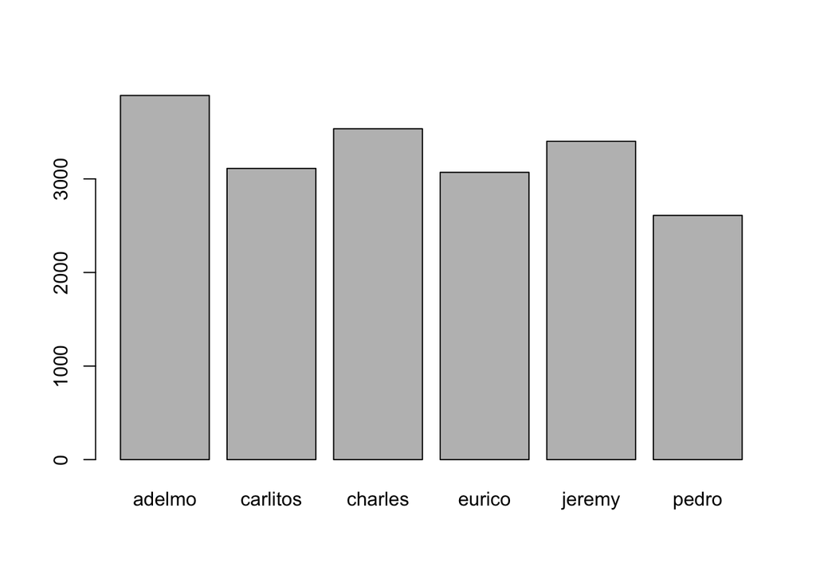

```r
plot(Train$user_name, )
```

```r
levels(CTrain$classe)
```

```
## [1] "A" "B" "C" "D" "E"
```

```r
Cpercent <- prop.table(table(CTrain$classe)) * 100
cbind(freq = table(Train$classe), percentage = Cpercent)
```

```
##   freq percentage
## A 5580   28.43747
## B 3797   19.35073
## C 3422   17.43961
## D 3216   16.38977
## E 3607   18.38243
```

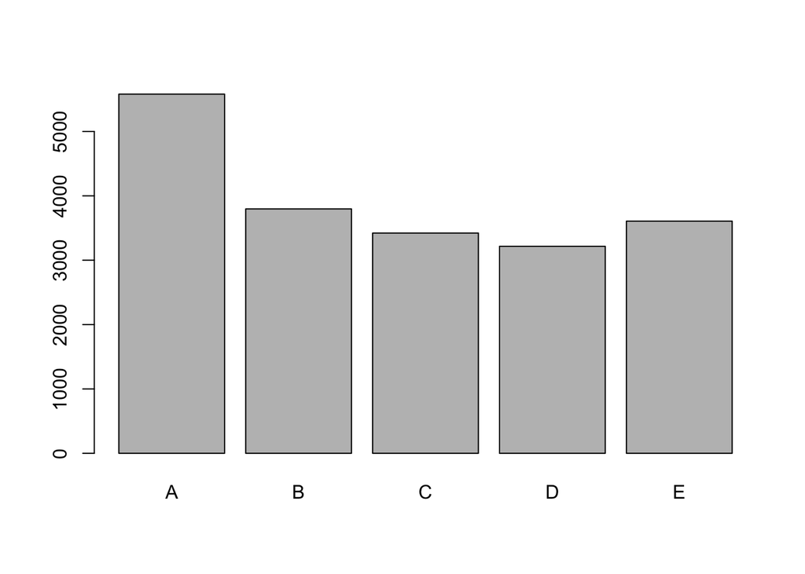

```r
plot(Train$classe, )
```

```r
### Remove likely unnecessary columns
TempTrain <- !names(CTrain) %in%
  c('X', 'user_name', 'raw_timestamp_part_1', 'raw_timestamp_part_2',
    'cvtd_timestamp', 'new_window')
CTrain <- CTrain[, TempTrain]
```

### Partition the training data for crossvalidation

Basic preparation of the training data to create a training and testing dataset that did not impede on the actual testing data.

```r
PTrain <- createDataPartition(CTrain$classe, p = 0.6)[[1]]
CrossV <- CTrain[-PTrain,]
PTrain <- CTrain[ PTrain, ]
PTrain <- createDataPartition(CrossV$classe, p = 0.75)[[1]]
CrossVtest <- CrossV[-PTrain, ]
CrossV <- CrossV[PTrain, ]
```

### Train different models

```r
mod1 <- train(classe ~ ., data=CTrain, method="rf")
mod2 <- train(classe ~ ., data=CTrain, method="gbm")
mod3 <- train(classe ~ ., data=CTrain, method="lda")

pred1 <- predict(mod1, CrossV)
pred2 <- predict(mod2, CrossV)
pred3 <- predict(mod3, CrossV)

### Confusion Matrices
confusionMatrix(pred1, CrossV$classe)
confusionMatrix(pred2, CrossV$classe)
confusionMatrix(pred3, CrossV$classe)

### Create Combination Model

Cmodel <- data.frame(pred1, pred2, classe=CrossV$classe)
Cmodel2 <- data.frame(pred2, pred3, classe=CrossV$classe)
Cmodel3 <- data.frame(pred1, pred2, pred3, classe=CrossV$classe)

CmodelFit <- train(classe ~ ., method="rf", data=Cmodel)
CmodelFit2 <- train(classe ~ ., method="rf", data=Cmodel2)
CmodelFit3 <- train(classe ~ ., method="rf", data=Cmodel3)

#### in-sample error
CmodelFitIn <- predict(CmodelFit, Cmodel)
CmodelFitIn2 <- predict(CmodelFit2, Cmodel)
CmodelFitIn3 <- predict(CmodelFit3, Cmodel)
confusionMatrix(CmodelFitIn, Cmodel$classe)
confusionMatrix(CmodelFitIn2, Cmodel$classe)
confusionMatrix(CmodelFitIn3, Cmodel$classe)

# ERROR NEEDS WORK out-of-sample error
pred1 <- predict(mod1, CrossV)
pred3 <- predict(mod3, CrossV)
confusionMatrix(pred1, CrossVtest$classe)
```

[output not shown]

### Random Forest

The Random Forest model with a 5-fold cross validation will be used as the predictor rather than the other methods or a combination of methods.  
* RF handls large input well, including when the interacations are unknown.  
* RF has built-in cross-validation that estimates the out-of-sample error rate.

Then, I explored the model with various data visualizations, including a list of the top variables.

```r
RFmodel <- train(classe ~., data=CTrain, method = "rf",
                 trControl = trainControl(method = "cv", number = 5))
save(RFmodel, file = "RFmodel2.Rda")
print(RFmodel)
```

```
## Random Forest
##
## 19622 samples
##    53 predictor
##     5 classes: 'A', 'B', 'C', 'D', 'E'
##
## No pre-processing
## Resampling: Cross-Validated (5 fold)
## Summary of sample sizes: 15697, 15699, 15697, 15698, 15697
## Resampling results across tuning parameters:
##
##   mtry  Accuracy   Kappa
##    2    0.9962287  0.9952296
##   27    0.9984711  0.9980662
##   53    0.9960759  0.9950359
##
## Accuracy was used to select the optimal model using the largest value.
## The final value used for the model was mtry = 27.
```

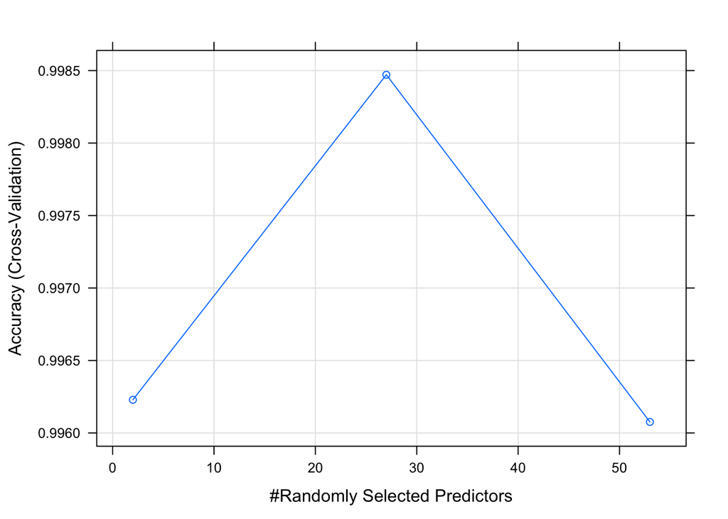

```r
plot(RFmodel)
```

```r
varImp(RFmodel)
```

```
## rf variable importance
##
##   only 20 most important variables shown (out of 53)
##
##                      Overall
## num_window           100.000
## roll_belt             61.803
## pitch_forearm         37.701
## yaw_belt              31.640
## magnet_dumbbell_z     28.210
## magnet_dumbbell_y     27.872
## pitch_belt            27.056
## roll_forearm          22.823
## accel_dumbbell_y      12.473
## roll_dumbbell         10.433
## accel_belt_z          10.374
## magnet_dumbbell_x     10.314
## accel_forearm_x        9.818
## total_accel_dumbbell   8.911
## accel_dumbbell_z       7.930
## magnet_forearm_z       7.043
## magnet_belt_z          6.868
## magnet_belt_y          6.436
## magnet_belt_x          5.569
## roll_arm               5.141
```

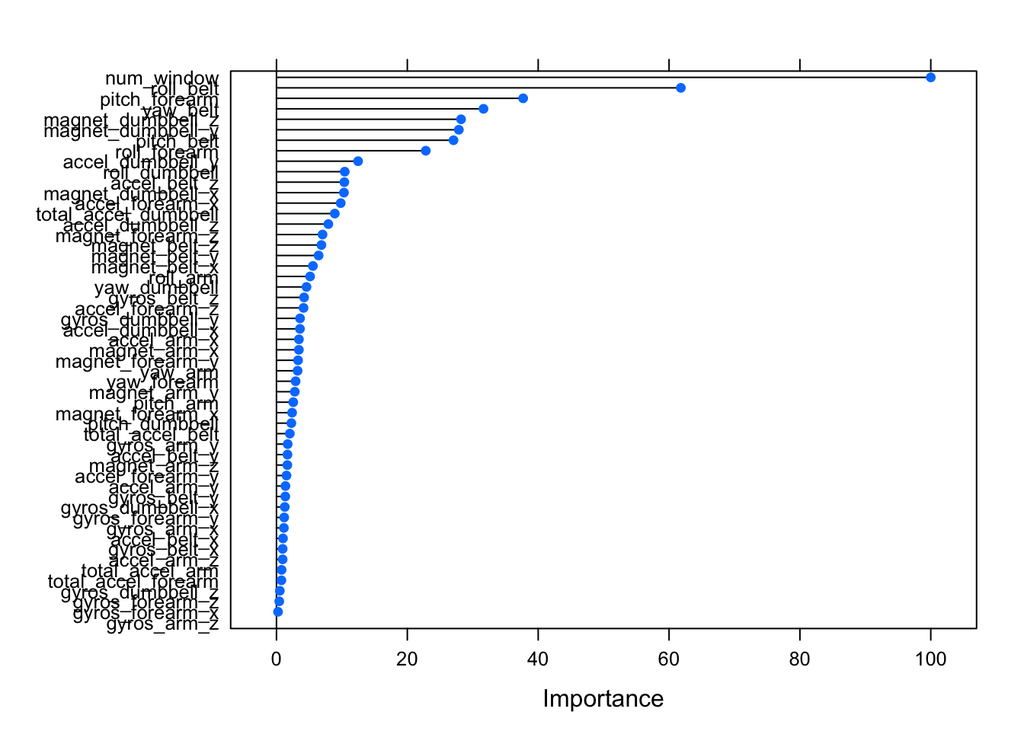

```r
plot(varImp(RFmodel))
```

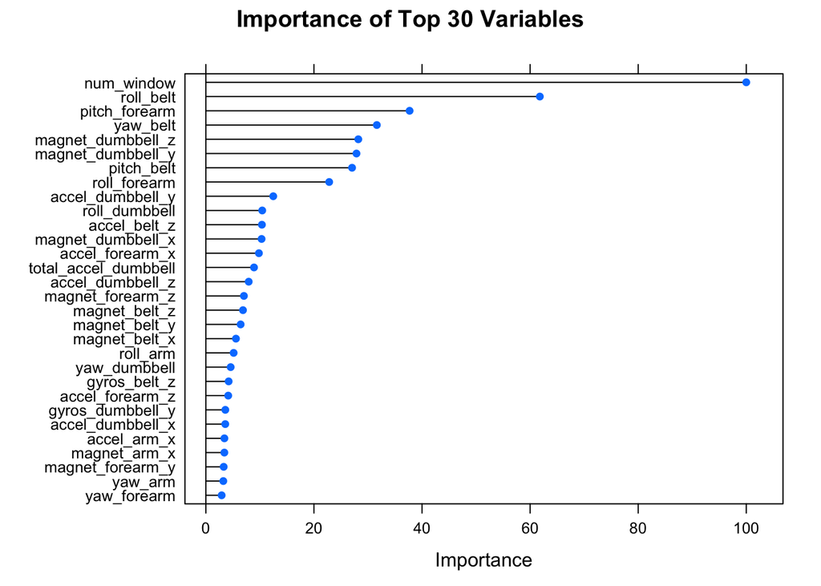

```r
plot(varImp(RFmodel), main = "Importance of Top 30 Variables", top = 30)
```

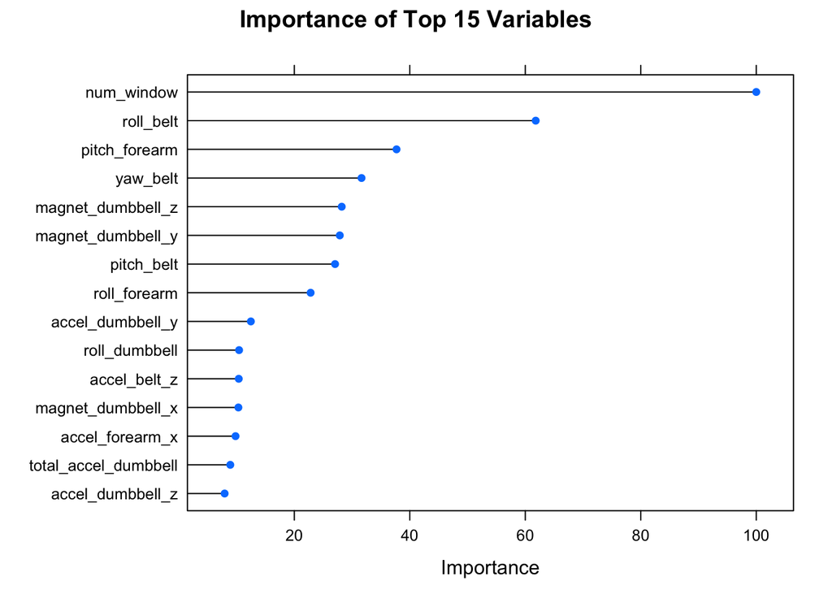

```r
plot(varImp(RFmodel), main = "Importance of Top 15 Variables", top = 15)
```

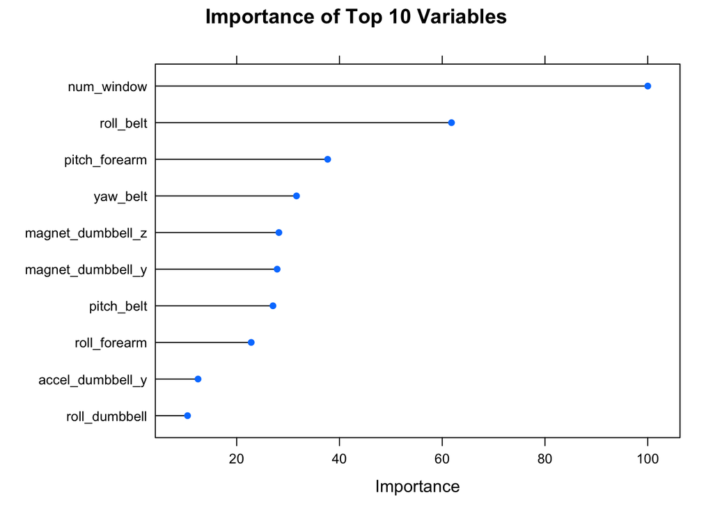

```r
plot(varImp(RFmodel), main = "Importance of Top 10 Variables", top = 10)
```

```r
RFmodel$finalModel
```

```
##
## Call:
##  randomForest(x = x, y = y, mtry = param$mtry)
##                Type of random forest: classification
##                      Number of trees: 500
## No. of variables tried at each split: 27
##
##         OOB estimate of  error rate: 0.13%
## Confusion matrix:
##      A    B    C    D    E  class.error
## A 5578    1    0    0    1 0.0003584229
## B    4 3790    2    1    0 0.0018435607
## C    0    5 3417    0    0 0.0014611338
## D    0    0    7 3207    2 0.0027985075
## E    0    0    0    2 3605 0.0005544774
```

#### Let’s test the prediction

Intersected the cleaned training data with the testing data to ensure that I had the same variables, and then ran predictions against the testing data.

```r
CTest <- Test[ , intersect(names(CTrain), names(Test))]
RFpredict <- predict(RFmodel, CTest)
confusionMatrix(RFmodel, Test$classe)
```

```
## Cross-Validated (5 fold) Confusion Matrix
##
## (entries are un-normalized aggregated counts)
##
##           Reference
## Prediction    A    B    C    D    E
##          A 5578    6    0    0    0
##          B    1 3788    6    0    0
##          C    0    2 3416   10    0
##          D    0    1    0 3205    2
##          E    1    0    0    1 3605
##
##  Accuracy (average) : 0.9985
```